# Size matters: using machine learning techniques to predict the age of abalone from different measures of size

Holder A, Vucinich S, Welch J

May 13, 2018

### Introduction

Abalone are single shelled sessile snails that inhabit the intertidal zone of marine ecosystems. Overexploitation, ocean acidification, and disease on the West Coast of the United States have significantly reduced population sizes for many species. As a result, two species (white and black) have been listed as federally endangered under the Endangered Species Act and three other species (pink, green, pinto) are part of the Species of Concern Program. There is tremendous interest to improve our understanding of these species so we can rebuild and conserve their populations.

Understainding the population biology of a species is critical for successful conservation and management. Unfortunately, obtaining the data required to make informed decisions (e.g. age of individuals, reproductive strategies) can be arduous and expensive. For abalone, an individua’s age is determined by cutting the shell through the cone, staining it, and counting the number of rings (similar in concept to aging a tree). As one might expect, this method disrupts individuals, is time consuming, and can become expensive to collect.

Here, we attempt to address this issue and better understand to what extent different measures of size can be used to predict the age of abalone. We also wanted to investigate which machine learning method would be the most effective at prediction using this dataset. Specifically, we compared: linear regression, classfication trees, and K Nearest Neighbors (KNN) regression.

### Data

Warwick *et al.* (1994) conducted a study on the population biology of abalone (*Haliotis* species) in Tasmania. Data from that study has been made publically available by the UC Irvine Machine Learning Repository (Repository) (https://archive.ics.uci.edu/ml/datasets/Abalone), and was downloaded from the repository on May 3, 2018.

```r
# Set Working Directory
rm(list = ls()); graphics.off()
setwd("C:/Users/AHolder/Documents/01_School/CSUMB_Grad/18_S/CST383_IntroToDataScience/Homework/HW15_Project2")

#Read in the data
dat = read.csv("abalone.csv")

#How many rows/columns?
nrw <- nrow(dat)
ncl <- ncol(dat)

colnames(dat) <- c("Sex", "Length", "Diameter", "Height", "Weight_W", "Weight_Shk", "Weight_V", "Weight_Shl", "Rings")
```

The dataset was comprised of nine (9) columns and 4176 rows, with eight potential predictor variables and one response (Table 1).

Table 1. Variable names, descriptions, whether or not they were considered to be a predictor or the response, and whether they were continuous or categorical.

| Variable | Variable Description (units) | pred/resp | cont/cat |
| --- | --- | --- | --- |
| Sex | Male, Female, or Infant (M,F,I) | predictor | categorical |
| Length | Longest shell measurement (mm) | predictor | continuous |
| Diameter | Perpendicular to length (mm) | predictor | continuous |
| Height | Measured with meat in shell (mm) | predictor | continuous |
| Weight_W | Whole abalone weight (g) | predictor | continuous |
| Weight_Shk | Shucked weight (weight of meat; g) | predictor | continuous |
| Weight_V | Viscera weight (gut weight after bleeding; g) | predictor | continuous |
| Weight_Shl | Shell weight after being dried (g) | predictor | continuous |
| Rings | Number of rings (+1.5 gives the age in years) | response | continuous |

### Data Exploration

```r
#Look at the structure of the data
#str(dat)
#Summarize data
#summary(dat)

#Find # complete cases
compcases <- nrow(dat[complete.cases(dat)==TRUE,])/nrw*100

#Find % of NA by column
perc.NA = apply(dat,2,function(x) round(mean(is.na(dat)),2))

#Find % of empty spaces by column
perc.empty <- apply(dat,2,function(x) round(mean(x == ""),2))
```

We analyzed the structure of the data, general trends of and among variables, and how complete the dataset was. None of the columns contained NA values or empty strings; 100% of the records in the dataset were complete.

### Data Preprocessing

The data we downloaded from the Repository was already scaled and our initial data exploration showed that very little preprocessing was necessary. However, we did decide to add an “Age” column to the dataset and remove the “Rings” column so we could predict age directly. Age was calculated by adding 1.5 to the number or rings for each record (Warwick *et al.* 1994).

```r
#Add Age column
dat$Age <- dat$Rings+1.5

#Remove Rings column
dat <- dat[,-9]
```

### Data Exploration

We first explored how the continuous predictor variables were related to each other (i.e. correlation/collinearity). Unsurprisingly, we noticed that many variables appeared to be highly correlated.

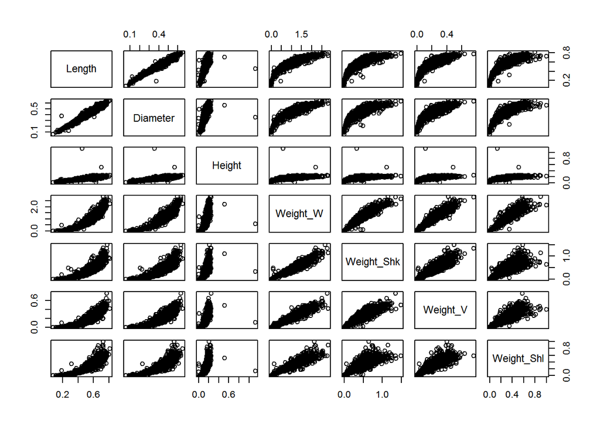

```r
plot(dat[,2:8])
```

To understand the severity of the collinearity, we created a correlation plot of the continuous variables, which confirmed that all variables were strongly positively correlated.

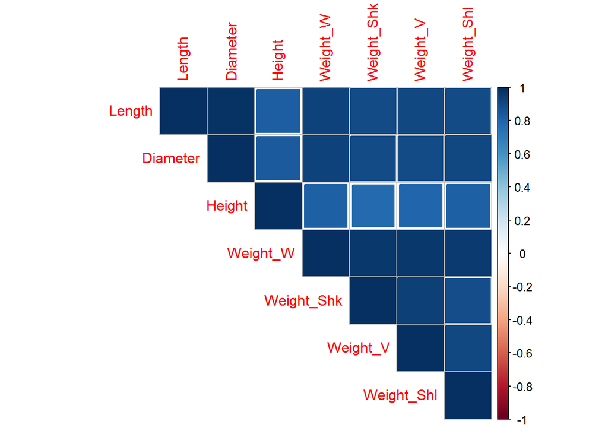

```r
#Correlation Plot
corrplot(cor(dat[,2:8]),type = "upper",method = "square",mar = c(0.1,0.1,0.2,0.5))
```